# DATA607 Week 11 Assignment

Gabriel Campos

April 21 2021

# Assignment

## Overview

[Building the Next New York Times Recommendation Engine - The New York Times.pdf](https://bbhosted.cuny.edu/bbcswebdav/pid-2729570-dt-forum-rid-425095280_1/xid-425095280_1)

[Amazon-Recommendations Item to Item Collaborative Filtering .pdf](https://bbhosted.cuny.edu/bbcswebdav/pid-2729570-dt-forum-rid-425095281_1/xid-425095281_1)

Your task is to analyze an existing recommender system that you find interesting. You should:

1. Perform a Scenario Design analysis as described below. Consider whether it makes sense for your selected recommender system to perform scenario design twice, once for the organization (e.g. Amazon.com) and once for the organization’s customers.
2. Attempt to reverse engineer what you can about the site, from the site interface and any available information that you can find on the Internet or elsewhere.
3. Include specific recommendations about how to improve the site’s recommendation capabilities going forward.
4. Create your report using an R Markdown file, and create a discussion thread with a link to the GitHub repo where your Markdown file notebook resides. You are not expected to need to write code for this discussion assignment.

## Examples

Here are two examples of the kinds of papers that might be helpful backgrounders for your research in #2 above (if you had chosen amazon.com or nytimes.com as your web site):

- Greg Linden, Brent Smith, and Jeremy York (2003): [Amazon.com Recommendations: Item-to-Item Collaborative Filtering](https://datajobs.com/data-science-repo/Recommender-Systems-%5BAmazon%5D.pdf), IEEE Internet Computing.
- Alex Spangher (2015): [Building the Next New York Times Recommendation Engine](http://open.blogs.nytimes.com/2015/08/11/building-the-next-new-york-times-recommendation-engine/)

## How to Perform a Scenario Analysis (review).

Scenario Design is an easy-to-use “three question framework” that helps you in making sure that the information in your analysis work takes UX (user experience) into account:

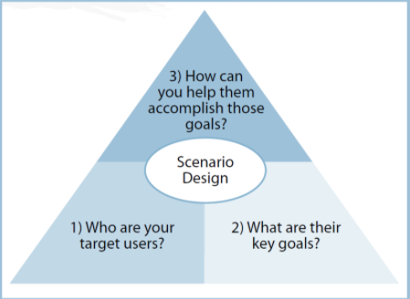

Source: “Scenario Design: A Disciplined Approach to Customer Experience,” Bruce D. Temkin, Forrester Research, 2004. Temkin notes that before applying Scenario Design, one might ask, “What functionality should we offer?” After applying Scenario Design, one might instead ask, “What user goals should we serve?”

## Task

Your task is to:

1. Identify a recommender system web site, then
2. Answer the three scenario design questions for this web site.

This process of guessing/reverse engineering, while inexact, will help you build out your own ability to better account for “user needs” in designing recommender systems going forward. Being able to place the customer first in your mind is a “soft skill” that is highly valued in the technical marketplace.

*You may work in a small group on this discussion assignment! Please make your initial post (which includes a link to your GitHub hosted R Markdown file before our meetup on Wednesday, and provide feedback to at least one of your class mates’ posts before end of day on Sunday. Your feedback should include at least one additional reference and/or constructive suggestion.*

# GrubHub

[figure not shown]

## Scenario Design

**3 Question Framework**

**1**. **Who are your target users?**

- Customers hoping to have food delivered, Restaurants trying to increase business, Couriers earning off deliveries.

**2**. **What are there key goals?**

- The key goals are:
  - To ensure consumers are provided information of local restaurants and their menu, based on their current geographic location.
  - Have restaurants provide up to date information regarding pricing and products.
  - Have new businesses register on their sites.

The focus here will be the consumer, as recommender systems are driven by there interaction with the site/application.

## Reverse Engineer

Grub Hub’s recommender system, relies heavily on tidying it’s data from the restaurants menus. The reason for this is because restaurant try their best to stand out, and in doing so, make all the items in their menu as unique as possible. Burgers from diners vs fast food restaurants vs high end restaurants, can be labeled *“bistro”*, *“slider”*, *“garden”*, etc. complicating there categorization. Wording in the description of the menu items can use non standard spelling, or use a identifier that changes the entire *“flavor”* of a food item (Japanese curry vs Indian curry). To address this grubhub:

1. collects menus of all of its restaurant clients (over 14 million)
2. Use logs and reviews (internal and external) to compare customer orders with end results at a restaurant.
3. Review customer historical data focusing on frequency and item quantity.

To refine the above skeletal structure, GrubHub uses a *“cuisine dictionary”* that is implemented similar to a sentiment analysis by categorizing these items.

The end result is a loosely tied algorithm that allows for recommendation to its consumers that encourages user continued purchases.

## Recommendations

Suggestions to improve the site’s recommencation effectiveness may be:

- A larger *“cuisine dictionary”*. As of 2018, the dictionary in question had around 4,000 main categories plus additional sub categories. This does not cover the variety of food nationwide and worldwide, specifically when noting hybrid cuisines.
- Draw relationships from staff. Chefs often influence or are influenced by each other, drawing links between cooking styles, mentors, mentees, culinary schools etc. is a category that can be used to better recommend consumers.
- Coordinate with Airbnb and other applications that involve travel such as trip adviser. GrubHub me be able to influence it’s clientele into researching new areas to travel based on the type of local cuisine. Most travel programs, highlight specialty dishes specific to a region and collaboration with other applications can lead to better revenue.

# References

1. 2021. [online] Available at: https://www.ncrypted.net/blog/how-does-grubhub-work/ [Accessed 22 April 2021].
2. Rogers, A., 2021. How Grubhub Analyzed 4,000 Dishes to Predict Your Next Order. [online] Wired. Available at: https://www.wired.com/story/how-grubhub-analyzed-4000-dishes-to-predict-your-next-order/ [Accessed 22 April 2021].